# Project

Bob Ding, Lynn Fan, Alice Jiang

11/18/2018

# Data Exploration

```r
# input data source
data <- read.csv("./redwine_quality.csv")
```

```r
# overview of the dataset
glimpse(data)
```

```
## Observations: 1,599
## Variables: 12
## $ fixed.acidity        <dbl> 7.4, 7.8, 7.8, 11.2, 7.4, 7.4, 7.9, 7.3, ...
## $ volatile.acidity     <dbl> 0.700, 0.880, 0.760, 0.280, 0.700, 0.660,...
## $ citric.acid          <dbl> 0.00, 0.00, 0.04, 0.56, 0.00, 0.00, 0.06,...
## $ residual.sugar       <dbl> 1.9, 2.6, 2.3, 1.9, 1.9, 1.8, 1.6, 1.2, 2...
## $ chlorides            <dbl> 0.076, 0.098, 0.092, 0.075, 0.076, 0.075,...
## $ free.sulfur.dioxide  <dbl> 11, 25, 15, 17, 11, 13, 15, 15, 9, 17, 15...
## $ total.sulfur.dioxide <dbl> 34, 67, 54, 60, 34, 40, 59, 21, 18, 102, ...
## $ density              <dbl> 0.9978, 0.9968, 0.9970, 0.9980, 0.9978, 0...
## $ pH                   <dbl> 3.51, 3.20, 3.26, 3.16, 3.51, 3.51, 3.30,...
## $ sulphates            <dbl> 0.56, 0.68, 0.65, 0.58, 0.56, 0.56, 0.46,...
## $ alcohol              <dbl> 9.4, 9.8, 9.8, 9.8, 9.4, 9.4, 9.4, 10.0, ...
## $ quality              <int> 5, 5, 5, 6, 5, 5, 5, 7, 7, 5, 5, 5, 5, 5,...
```

```r
# convert quality into factor variable
data <- data %>% mutate(quality = as.factor(quality))
```

```r
# duplicate quality for ordinal regresison
data <- data %>% mutate(quality_dup = as.factor(quality))
```

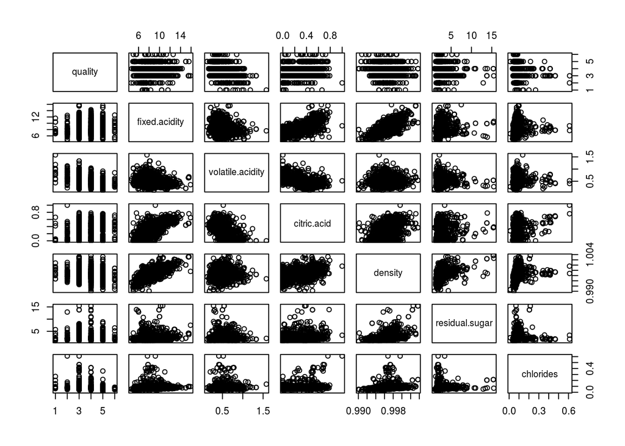

```r
# scatter plot matrix one
pairs(quality ~ fixed.acidity + volatile.acidity + citric.acid + density + residual.sugar + chlorides, data=data)
```

```r
# correlation coefficients for potential multicollinearity
cor(data$fixed.acidity, data$citric.acid)
```

```
## [1] 0.6717034
```

```r
cor(data$fixed.acidity, data$density)
```

```
## [1] 0.6680473
```

```r
cor(data$volatile.acidity, data$citric.acid)
```

```
## [1] -0.5524957
```

```r
cor(data$density, data$residual.sugar)
```

```
## [1] 0.3552834
```

The correlation coefficent for fixed.acidity and citric.acid (0.6717034) and the correlation coefficient for fixed.acidity and density (0.6680473) show moderate to strong linear relationship between the variables. To remove potential multicollinearity impact, we **will not include fixed.acidity** in the model.

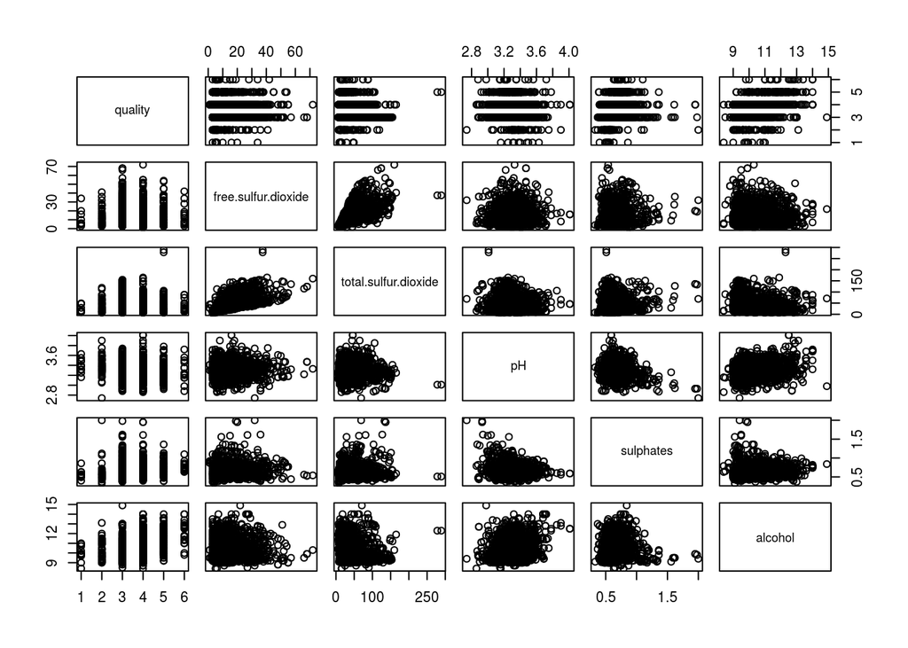

```r
# scatter plot matrix two
pairs(quality ~ free.sulfur.dioxide + total.sulfur.dioxide + pH + sulphates + alcohol, data=data)
```

The scatter plot shows strong positive linear relationship between free.sulfur.dioxide and total.sulfur.dioxide.

```r
# correlation coefficients for potential multicollinearity
cor(data$free.sulfur.dioxide, data$total.sulfur.dioxide)
```

```
## [1] 0.6676665
```

The correlation coefficient of 0.6676665 between free.sulfur.dioxide and total.sulfur.dioxide indicates strong positive linear relationship. We also know from the data description that total.sulfur dioxide includes free.sulfur.dioxide - whose concentration level could impact the smell and taste of the wine, thus impacting quality. So it is sufficient to include only one of these two variables in the model, and we **will include free.sulphur.dioxide**.

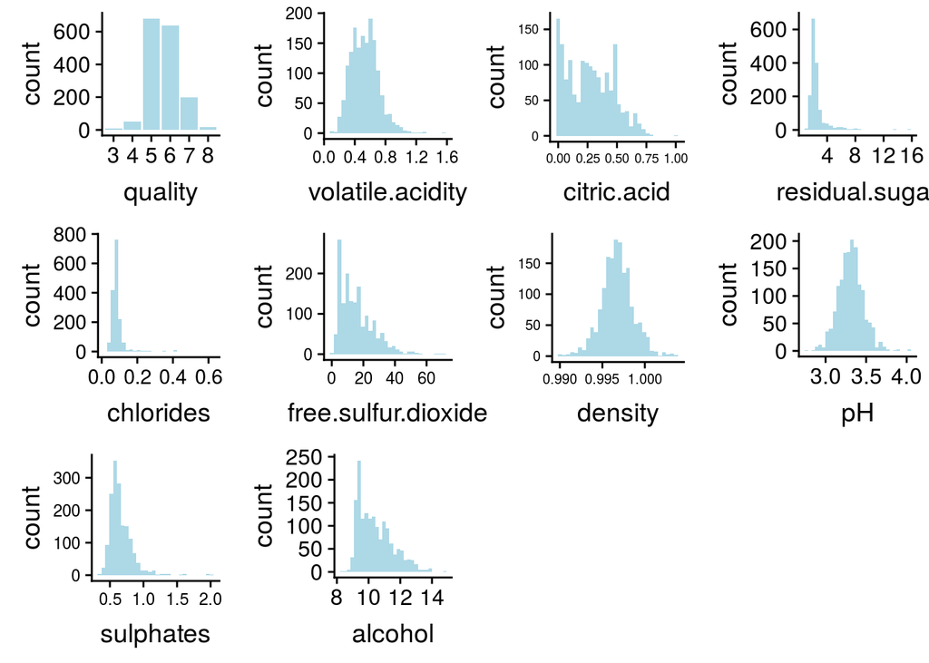

```r
# distribution of each variable
p1  <- ggplot(data = data, aes(x = quality) ) + geom_histogram(stat="count",fill= "lightblue")
p2  <- ggplot(data = data, aes(x = volatile.acidity) ) + theme(axis.text=element_text(size=9)) + geom_histogram(fill= "lightblue")
p3  <- ggplot(data = data, aes(x = citric.acid) ) + theme(axis.text=element_text(size=7)) + geom_histogram(fill= "lightblue")
p4  <- ggplot(data = data, aes(x = residual.sugar) ) + geom_histogram(fill= "lightblue")
p5  <- ggplot(data = data, aes(x = chlorides) ) + theme(axis.text=element_text(size=11)) + geom_histogram(fill= "lightblue")
p6  <- ggplot(data = data, aes(x = free.sulfur.dioxide) ) + theme(axis.text=element_text(size=9)) + geom_histogram(fill= "lightblue")
p7  <- ggplot(data = data, aes(x = density) ) + theme(axis.text=element_text(size=7.5)) + geom_histogram(fill= "lightblue")
p8 <- ggplot(data = data, aes(x = pH) ) + geom_histogram(fill= "lightblue")
p9 <- ggplot(data = data, aes(x = sulphates) ) + theme(axis.text=element_text(size=9)) + geom_histogram(fill= "lightblue")
p10 <- ggplot(data = data, aes(x = alcohol) ) + geom_histogram(fill= "lightblue")

plot_grid(p1,p2,p3,p4,p5,p6,p7,p8,p9,p10,ncol=4,nrow=3)
```

```r
# log transform sulphates
data <- data %>% mutate(log_sulphates = log(sulphates))
```

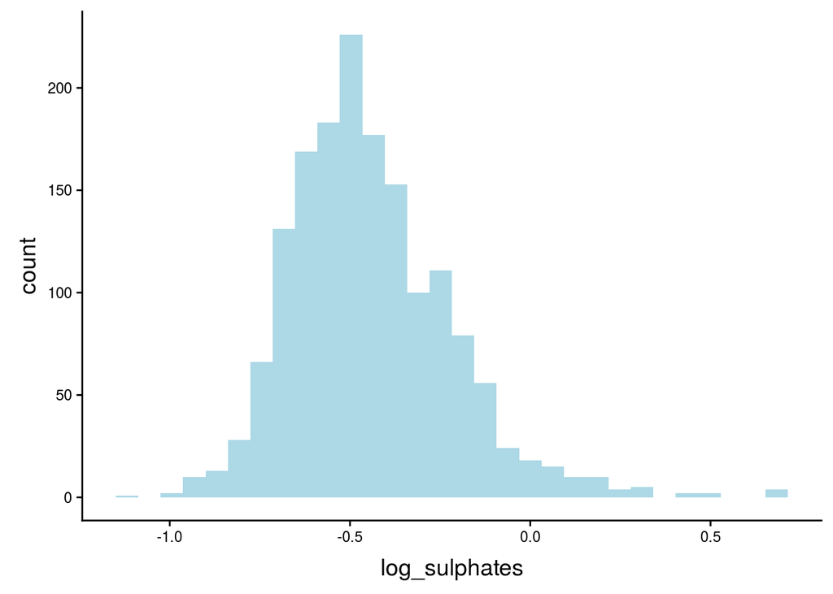

```r
# distribution of the log transformed sulphates
ggplot(data = data, aes(x = log_sulphates) ) + theme(axis.text=element_text(size=9)) + geom_histogram(fill= "lightblue")
```

```r
# summary statistics of each variable
summary(data)
```

```
##  fixed.acidity   volatile.acidity  citric.acid    residual.sugar
##  Min.   : 4.60   Min.   :0.1200   Min.   :0.000   Min.   : 0.900
##  1st Qu.: 7.10   1st Qu.:0.3900   1st Qu.:0.090   1st Qu.: 1.900
##  Median : 7.90   Median :0.5200   Median :0.260   Median : 2.200
##  Mean   : 8.32   Mean   :0.5278   Mean   :0.271   Mean   : 2.539
##  3rd Qu.: 9.20   3rd Qu.:0.6400   3rd Qu.:0.420   3rd Qu.: 2.600
##  Max.   :15.90   Max.   :1.5800   Max.   :1.000   Max.   :15.500
##    chlorides       free.sulfur.dioxide total.sulfur.dioxide
##  Min.   :0.01200   Min.   : 1.00       Min.   :  6.00
##  1st Qu.:0.07000   1st Qu.: 7.00       1st Qu.: 22.00
##  Median :0.07900   Median :14.00       Median : 38.00
##  Mean   :0.08747   Mean   :15.87       Mean   : 46.47
##  3rd Qu.:0.09000   3rd Qu.:21.00       3rd Qu.: 62.00
##  Max.   :0.61100   Max.   :72.00       Max.   :289.00
##     density             pH          sulphates         alcohol      quality
##  Min.   :0.9901   Min.   :2.740   Min.   :0.3300   Min.   : 8.40   3: 10
##  1st Qu.:0.9956   1st Qu.:3.210   1st Qu.:0.5500   1st Qu.: 9.50   4: 53
##  Median :0.9968   Median :3.310   Median :0.6200   Median :10.20   5:681
##  Mean   :0.9967   Mean   :3.311   Mean   :0.6581   Mean   :10.42   6:638
##  3rd Qu.:0.9978   3rd Qu.:3.400   3rd Qu.:0.7300   3rd Qu.:11.10   7:199
##  Max.   :1.0037   Max.   :4.010   Max.   :2.0000   Max.   :14.90   8: 18
##  quality_dup log_sulphates
##  3: 10       Min.   :-1.1087
##  4: 53       1st Qu.:-0.5978
##  5:681       Median :-0.4780
##  6:638       Mean   :-0.4453
##  7:199       3rd Qu.:-0.3147
##  8: 18       Max.   : 0.6931
```

From the previous histogram, we can see that quality has a fairly normal distribution. The summary statistic also shows that quality rating of 5 has the most number of observations (it is also the middle rating on the scale of 0-10). So quality rating of 5 is the most appropriate **reference level** for the model.

```r
# makes quality==5 the reference level
data <- data %>% mutate(quality = relevel(quality, ref=5))
```

```r
# add mean-centered numerical variables besides citric.acid
data <- data %>%
  mutate(volatile.acidityCent = volatile.acidity-mean(volatile.acidity),
         residual.sugarCent = residual.sugar-mean(residual.sugar),
         chloridesCent = chlorides-mean(chlorides),
         free.sulfur.dioxideCent = free.sulfur.dioxide-mean(free.sulfur.dioxide),
         densityCent = density-mean(density), pHCent = pH-mean(pH),
         alcoholCent = alcohol-mean(alcohol))
```

# Logistic Regression

```r
# transform quality into a binary variable
rawdata <- read.csv("./redwine_quality.csv")
data$quality <- rawdata$quality
data$quality[data$quality < 6] <- 0    # any quality less than 6 is 0 (not good)
data$quality[data$quality >= 6] <- 1   # quality equal to or greater than 6 so 6-10 is 1 (good)
```

```r
# Model Reduced
modellg1.null <- glm(quality ~ 1, data=data , family=binomial)

# Model Full
modellg1.full <- glm(quality ~ volatile.acidityCent + residual.sugarCent + citric.acid + chloridesCent + free.sulfur.dioxideCent + log_sulphates + densityCent + pHCent + alcoholCent, data=data, family = binomial)
```

```r
# forward Selection
step(modellg1.null, scope=list(upper=modellg1.full), direction="forward")
```

```
## Start:  AIC=2210.97
## quality ~ 1
##
##                           Df Deviance    AIC
## + alcoholCent              1   1865.0 1869.0
## + volatile.acidityCent     1   2033.4 2037.4
## + log_sulphates            1   2083.2 2087.2
## + densityCent              1   2167.8 2171.8
## + citric.acid              1   2168.0 2172.0
## + chloridesCent            1   2188.6 2192.6
## + free.sulfur.dioxideCent  1   2202.9 2206.9
## <none>                         2209.0 2211.0
## + pHCent                   1   2209.0 2213.0
## + residual.sugarCent       1   2209.0 2213.0
##
## Step:  AIC=1869.03
## quality ~ alcoholCent
##
##                           Df Deviance    AIC
## + volatile.acidityCent     1   1752.5 1758.5
## + log_sulphates            1   1778.0 1784.0
## + citric.acid              1   1841.4 1847.4
## + pHCent                   1   1846.8 1852.8
## + densityCent              1   1857.9 1863.9
## <none>                         1865.0 1869.0
## + free.sulfur.dioxideCent  1   1863.3 1869.3
## + residual.sugarCent       1   1864.2 1870.2
## + chloridesCent            1   1864.8 1870.8
##
## Step:  AIC=1758.5
## quality ~ alcoholCent + volatile.acidityCent
##
##                           Df Deviance    AIC
## + log_sulphates            1   1708.2 1716.2
## + free.sulfur.dioxideCent  1   1749.7 1757.7
## + densityCent              1   1750.1 1758.1
## <none>                         1752.5 1758.5
## + pHCent                   1   1750.7 1758.7
## + citric.acid              1   1750.8 1758.8
## + residual.sugarCent       1   1751.8 1759.8
```

[output cut: 40 more lines]

```
##
##                           Df Deviance    AIC
## + free.sulfur.dioxideCent  1   1681.3 1697.3
## <none>                         1685.9 1699.9
## + densityCent              1   1684.7 1700.7
## + residual.sugarCent       1   1685.7 1701.7
##
## Step:  AIC=1697.32
## quality ~ alcoholCent + volatile.acidityCent + log_sulphates +
##     chloridesCent + citric.acid + pHCent + free.sulfur.dioxideCent
##
##                      Df Deviance    AIC
## <none>                    1681.3 1697.3
## + densityCent         1   1680.2 1698.2
## + residual.sugarCent  1   1681.3 1699.3
```

```
##
## Call:  glm(formula = quality ~ alcoholCent + volatile.acidityCent +
##     log_sulphates + chloridesCent + citric.acid + pHCent + free.sulfur.dioxideCent,
##     family = binomial, data = data)
##
## Coefficients:
##             (Intercept)              alcoholCent     volatile.acidityCent
##                 1.74431                  0.97925                 -3.45469
##           log_sulphates            chloridesCent              citric.acid
##                 2.44978                 -4.21609                 -1.45283
##                  pHCent  free.sulfur.dioxideCent
##                -1.13296                 -0.01261
##
## Degrees of Freedom: 1598 Total (i.e. Null);  1591 Residual
## Null Deviance:       2209
## Residual Deviance: 1681  AIC: 1697
```

```r
# model based on forward selection
modellg1.final <- glm(quality ~ alcoholCent + volatile.acidityCent + log_sulphates + chloridesCent + free.sulfur.dioxideCent + citric.acid + pHCent, data=data, family = binomial)
summary(modellg1.final)
```

```
##
## Call:
## glm(formula = quality ~ alcoholCent + volatile.acidityCent +
##     log_sulphates + chloridesCent + free.sulfur.dioxideCent +
##     citric.acid + pHCent, family = binomial, data = data)
##
## Deviance Residuals:
##     Min       1Q   Median       3Q      Max
## -3.3473  -0.8646   0.3099   0.8434   2.3433
##
## Coefficients:
##                          Estimate Std. Error z value Pr(>|z|)
## (Intercept)              1.744307   0.214574   8.129 4.32e-16 ***
## alcoholCent              0.979245   0.073825  13.264  < 2e-16 ***
## volatile.acidityCent    -3.454692   0.459011  -7.526 5.22e-14 ***
## log_sulphates            2.449783   0.327225   7.487 7.07e-14 ***
## chloridesCent           -4.216093   1.442180  -2.923  0.00346 **
## free.sulfur.dioxideCent -0.012612   0.005922  -2.130  0.03320 *
## citric.acid             -1.452834   0.450223  -3.227  0.00125 **
## pHCent                  -1.132959   0.490441  -2.310  0.02088 *
## ---
## Signif. codes:  0 '***' 0.001 '**' 0.01 '*' 0.05 '.' 0.1 ' ' 1
##
## (Dispersion parameter for binomial family taken to be 1)
##
##     Null deviance: 2209.0  on 1598  degrees of freedom
## Residual deviance: 1681.3  on 1591  degrees of freedom
## AIC: 1697.3
##
## Number of Fisher Scoring iterations: 4
```

```r
# view coefficients of the selected model - the final model with main effects
kable(tidy(modellg1.final))
```

| term | estimate | std.error | statistic | p.value |
| --- | --- | --- | --- | --- |
| (Intercept) | 1.7443065 | 0.2145740 | 8.129161 | 0.0000000 |
| alcoholCent | 0.9792452 | 0.0738255 | 13.264325 | 0.0000000 |
| volatile.acidityCent | -3.4546919 | 0.4590113 | -7.526376 | 0.0000000 |
| log_sulphates | 2.4497829 | 0.3272250 | 7.486539 | 0.0000000 |
| chloridesCent | -4.2160930 | 1.4421799 | -2.923417 | 0.0034621 |
| free.sulfur.dioxideCent | -0.0126123 | 0.0059222 | -2.129659 | 0.0331998 |
| citric.acid | -1.4528340 | 0.4502233 | -3.226918 | 0.0012513 |
| pHCent | -1.1329592 | 0.4904405 | -2.310085 | 0.0208835 |

We can see that all the variables have p-values smaller than 0.05, so there is significant evidence that they are important predictors of the log-odds (and therefore odds) of wine quality (good vs. not good). Based on the model, it appears that the percent alcohol content of the wine is the strongest predictor of wine quality. alcoholCent has the largest test statistic magnitude of 13.264325. The positive test statistic value also shows that as the % alcohol content of the wine increases, the logs-odds of good vs. not good wine quality increases. The amount of acetic acid in wine (volatile.acidityCent) and the amount of wine additive (log_sulphates) are also strong predictors.

## Assumptions

```r
# calculate predicted probabilities
data$pred <- predict.glm(modellg1.final, type="response")
# calculate residuals of predicted probabilities
data$res <- residuals.glm(modellg1.final, type="response")
```

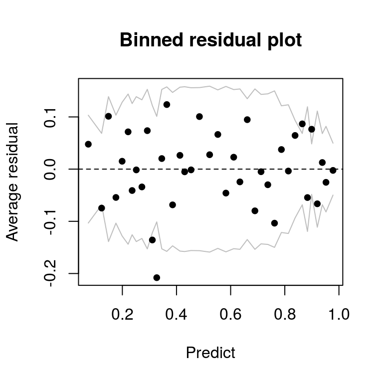

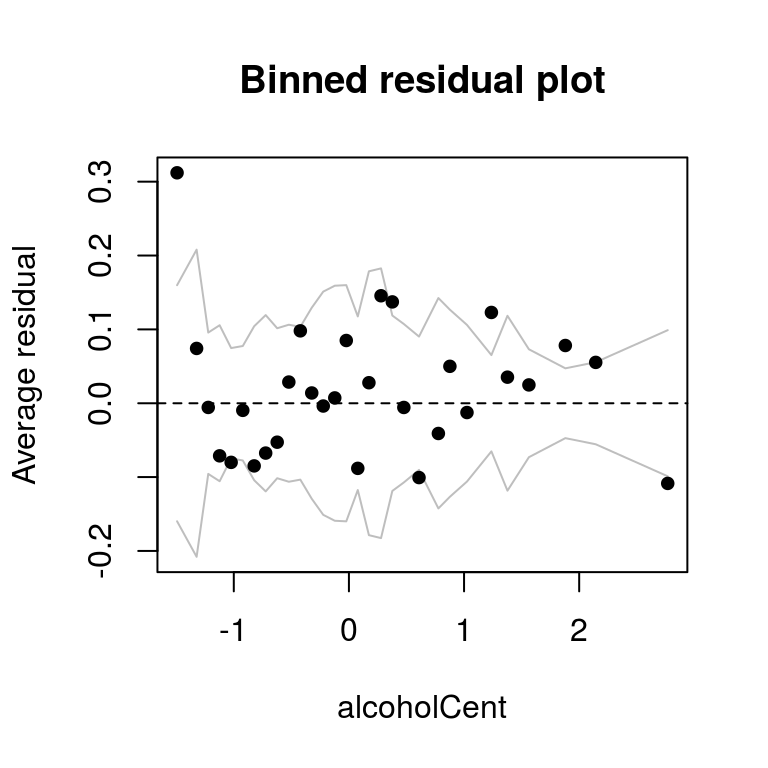

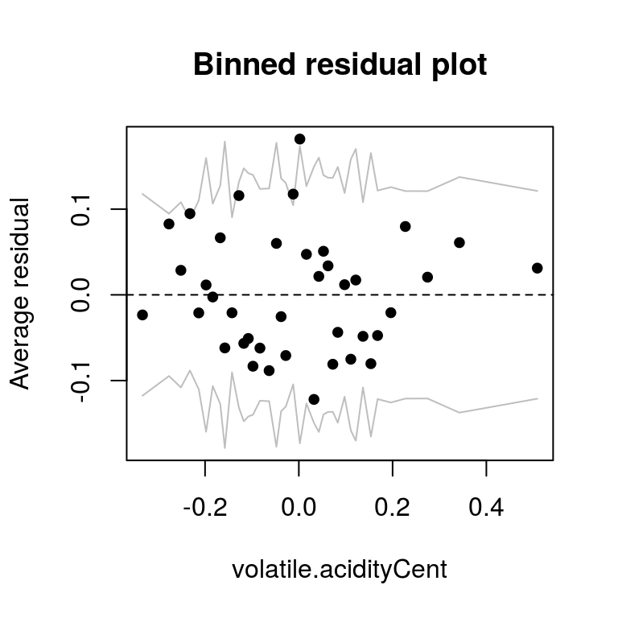

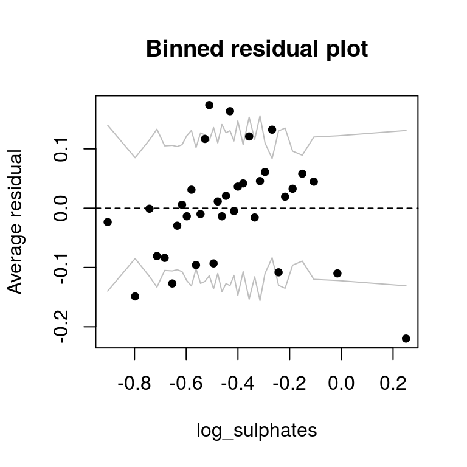

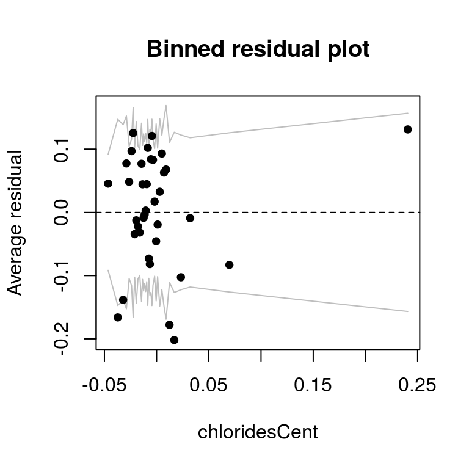

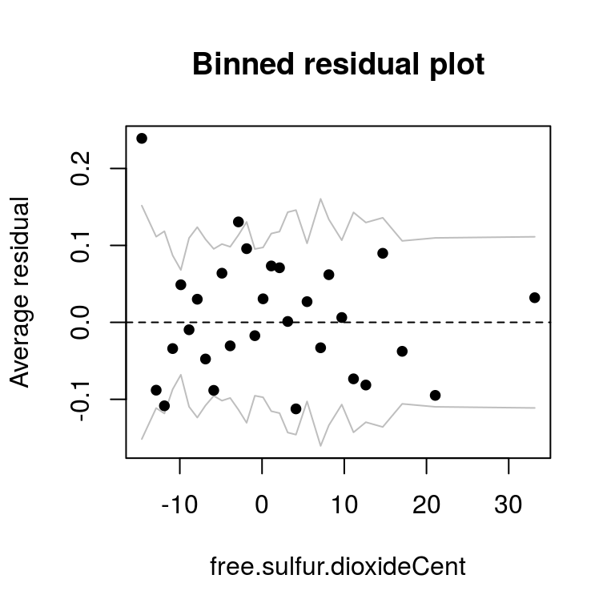

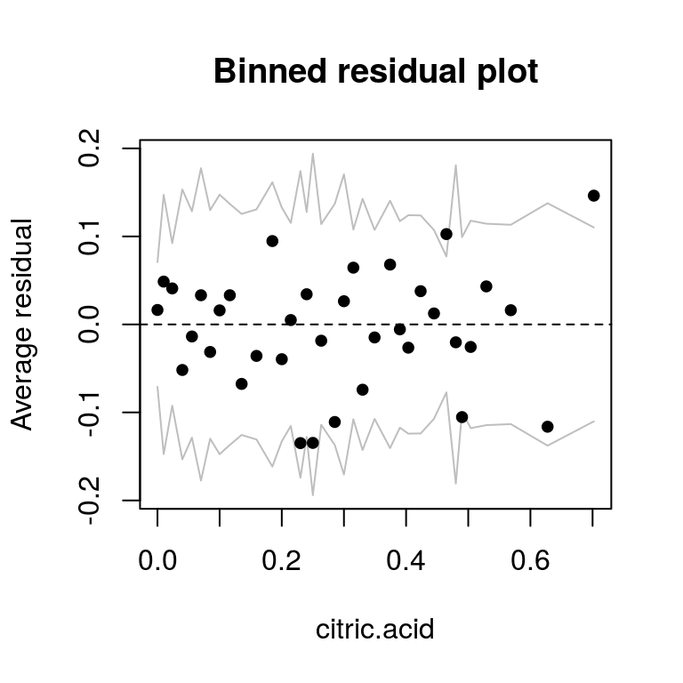

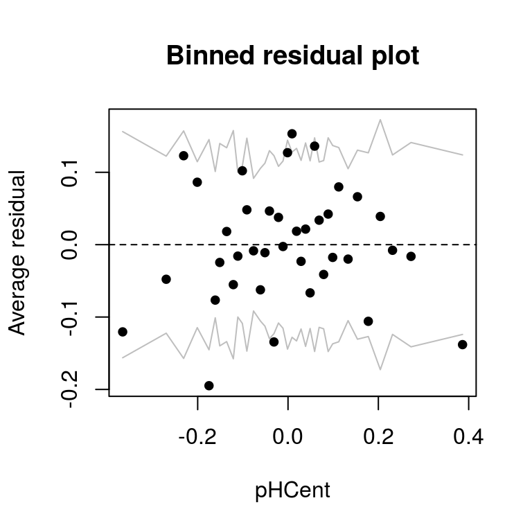

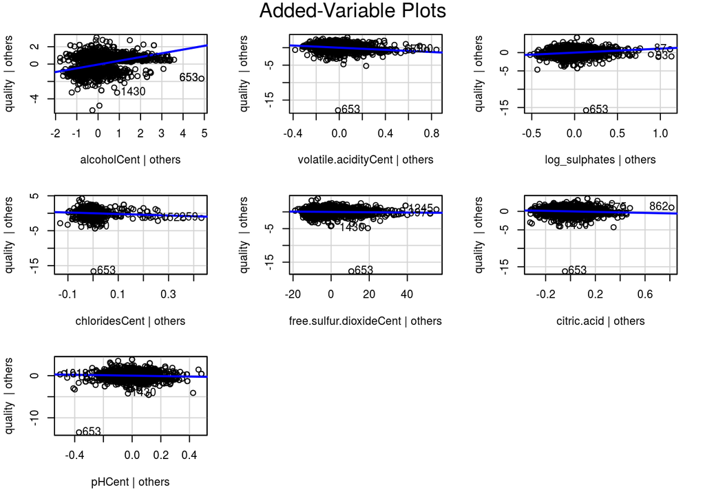

```r
# use AV Plot to identify prblematic observations
avPlots(modellg1.final)
```

We can see observations 653 is consistently identified in av plots. We might consider removing this point if it is influential.

```r
# influence points
data <- data %>%
  mutate(leverage = hatvalues(modellg1.final),
         cooks = cooks.distance(modellg1.final),
         stand.resid = rstandard(modellg1.final),
         obs.num = row_number())
```

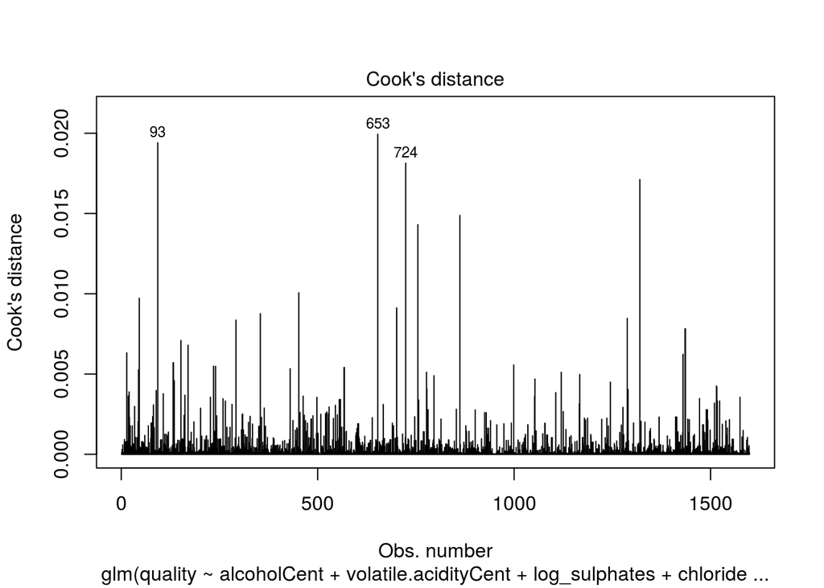

```r
# Cook's Distance
cutoff <- cooks.distance(modellg1.final)
plot(modellg1.final, which=4, cook.levels=cutoff)
```

We can see that observations 653, 93, and 724 have noticeably higher Cook’s Distance than other observations. However, their Cook’s Distance is still below 0.05 and is much smaller than the threshold of 1.

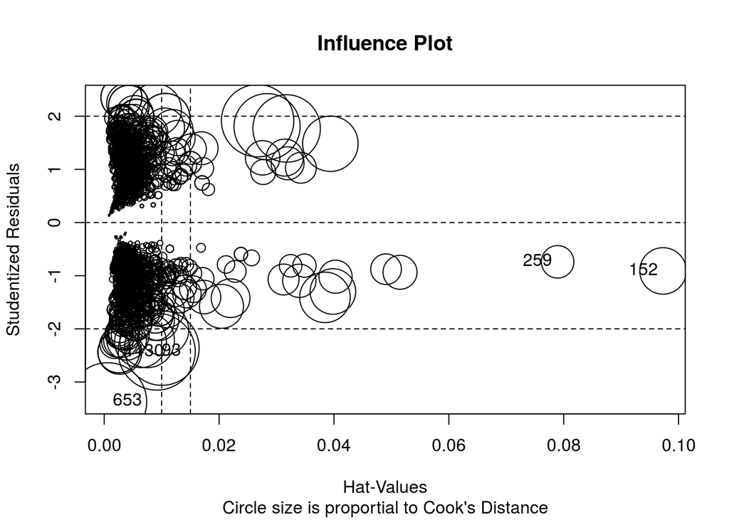

```
##         StudRes          Hat       CookD
## 93   -2.4287943 0.0091359820 0.019405024
## 152  -0.9101741 0.0972935691 0.007088194
## 259  -0.7393382 0.0789403851 0.003462105
## 653  -3.3710586 0.0005899936 0.019939563
## 1430 -2.4435909 0.0027063910 0.006228563
```

```r
# influence plot
influencePlot(modellg1.final, main="Influence Plot", sub="Circle size is proportial to Cook's Distance" )
```

We can see that some observations have high studentized residual value with magnitude greater than 2, but they have very low hat values and acceptable circle size. Observations 259 and 152 have very high leverage (hat values) but are within reasonable studentized residual value and circle size. Observation 653 has high magnitude of studentized residual, but very low leverage and reasonable circle size. Overall, there is no outstanding influence point in the data set, based on considerations of leverage and cook’s distance.

```r
# leverage threshold
threshold <- 0.05
```

Given we have 1599 observations and the above influence plot, we believe 0.05 is a reasonable threshold for leverage.

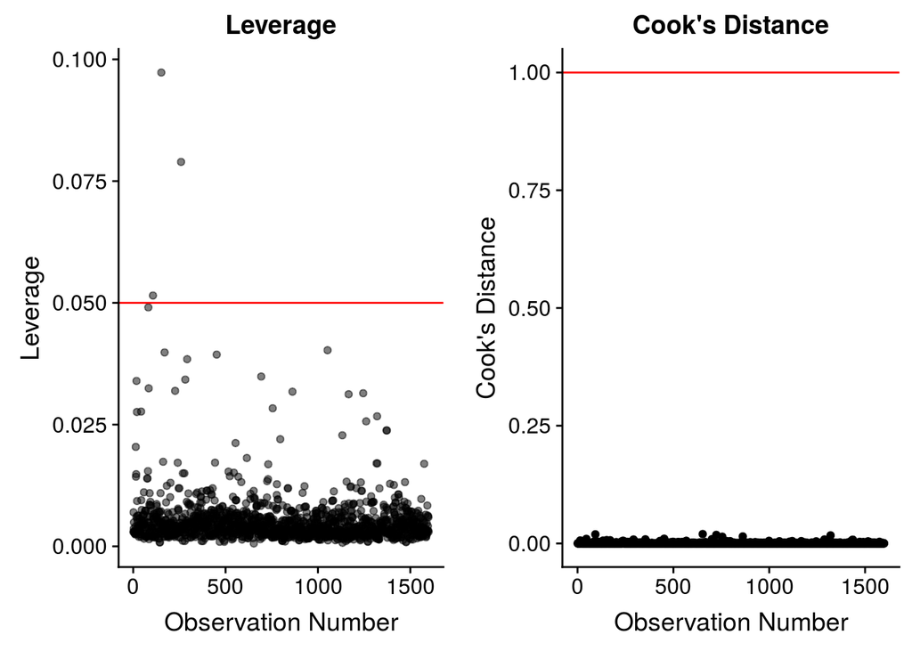

```r
# leverage and cook's distance plots
p1 <- ggplot(data=data, aes(x=obs.num,y=leverage)) +
  geom_point(alpha=0.5) +
  geom_hline(yintercept=threshold,color="red")+
  labs(x="Observation Number",y="Leverage",title="Leverage")

p2 <- ggplot(data=data, aes(x=obs.num,y=cooks)) +
  geom_point() +
  geom_hline(yintercept=1,color="red")+
  labs(x="Observation Number",y="Cook's Distance",title="Cook's Distance")

plot_grid(p1,p2,ncol = 2)
```

Overall, there is no significant influence point.

```r
# multicollinearity
kable(tidy(vif(modellg1.final)))
```

| names | x |
| --- | --- |
| alcoholCent | 1.128307 |
| volatile.acidityCent | 1.550398 |
| log_sulphates | 1.321746 |
| chloridesCent | 1.360013 |
| free.sulfur.dioxideCent | 1.026435 |
| citric.acid | 2.131671 |
| pHCent | 1.588385 |

VIF values are very small, so there is no major concerns of multicollinearity.

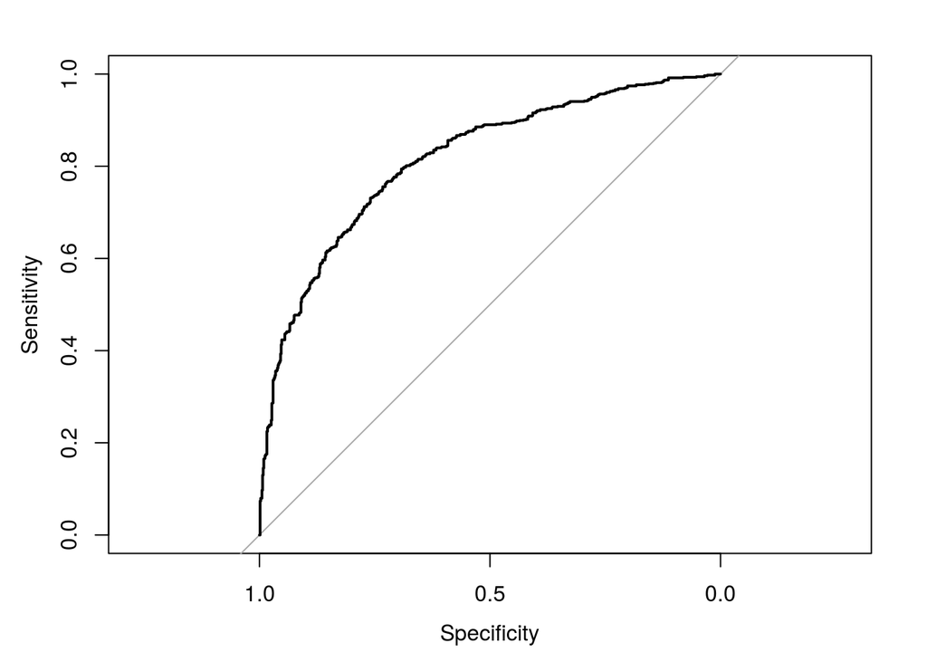

```r
# ROC Curve
ROC.quality <- roc(data$quality, data$pred, plot=T)
```

```r
# area under the curve
ROC.quality$auc
```

```
## Area under the curve: 0.8149
```

From the ROC curve and AUC calculation, we can see the curve is fairly close to the top left corner (area under the curve is close to 1). This shows that the logistic model is able to distinguish between good and not good quality, so this is a pretty good model.

## Interaction Effects in Logistic Regression

```r
# interaction effects with volatile.acidityCent using change in deviance test
# the final logistic regression model
modellg1.final <- glm(quality ~ alcoholCent + volatile.acidityCent + log_sulphates + chloridesCent + free.sulfur.dioxideCent + citric.acid + pHCent, data=data, family = binomial)
# new model for two-way interaction effects with volatile.acidityCent
modellg1 <- glm(quality ~ alcoholCent + volatile.acidityCent + log_sulphates + chloridesCent + free.sulfur.dioxideCent + citric.acid + pHCent + alcoholCent*volatile.acidityCent + volatile.acidityCent*log_sulphates + volatile.acidityCent*chloridesCent + volatile.acidityCent*free.sulfur.dioxideCent + volatile.acidityCent*citric.acid + volatile.acidityCent*pHCent, data=data, family = binomial)
tidy(anova(modellg1.final, modellg1, test="Chisq"))
```

```
## # A tibble: 2 x 5
##   Resid..Df Resid..Dev    df Deviance p.value
## *     <dbl>      <dbl> <dbl>    <dbl>   <dbl>
## 1      1591      1681.    NA    NA     NA
## 2      1585      1680.     6     1.45   0.963
```

p-value is greater than 0.05, so no interaction effects with volatile.acidityCent is a significant predictor.

```r
# interaction effects with citric.acid using change in deviance test
modellg2 <- glm(quality ~ alcoholCent + volatile.acidityCent + log_sulphates + chloridesCent + free.sulfur.dioxideCent + citric.acid + pHCent + alcoholCent*citric.acid + citric.acid*log_sulphates + citric.acid*chloridesCent + citric.acid*free.sulfur.dioxideCent + pHCent*citric.acid, data=data, family = binomial)
tidy(anova(modellg1.final, modellg2, test="Chisq"))
```

```
## # A tibble: 2 x 5
##   Resid..Df Resid..Dev    df Deviance p.value
## *     <dbl>      <dbl> <dbl>    <dbl>   <dbl>
## 1      1591      1681.    NA    NA     NA
## 2      1586      1676.     5     5.59   0.348
```

p-value is greater than 0.05, so interaction effects with citric.acid are not significant.

```r
# other possible two-way interaction effects
modellg3 <- glm(quality ~ alcoholCent + volatile.acidityCent + log_sulphates + chloridesCent + free.sulfur.dioxideCent + citric.acid + pHCent + alcoholCent*log_sulphates + alcoholCent*chloridesCent + alcoholCent*free.sulfur.dioxideCent + pHCent*alcoholCent* + log_sulphates*chloridesCent + log_sulphates*free.sulfur.dioxideCent + log_sulphates*pHCent + chloridesCent*free.sulfur.dioxideCent + chloridesCent*pHCent + free.sulfur.dioxideCent*pHCent, data=data, family = binomial)
tidy(anova(modellg1.final, modellg3, test="Chisq"))
```

```
## # A tibble: 2 x 5
##   Resid..Df Resid..Dev    df Deviance    p.value
## *     <dbl>      <dbl> <dbl>    <dbl>      <dbl>
## 1      1591      1681.    NA     NA   NA
## 2      1576      1633.    15     48.3  0.0000226
```

At least one of these two-way interaction effects is a significant predictor of log-odds of good wine vs. not good wine.

```r
# forward Selection
step(modellg1.null, scope=list(upper=modellg3), direction="forward")
```

```
## Start:  AIC=2210.97
## quality ~ 1
##
##                           Df Deviance    AIC
## + alcoholCent              1   1865.0 1869.0
## + volatile.acidityCent     1   2033.4 2037.4
## + log_sulphates            1   2083.2 2087.2
## + citric.acid              1   2168.0 2172.0
## + chloridesCent            1   2188.6 2192.6
## + free.sulfur.dioxideCent  1   2202.9 2206.9
## <none>                         2209.0 2211.0
## + pHCent                   1   2209.0 2213.0
##
## Step:  AIC=1869.03
## quality ~ alcoholCent
##
##                           Df Deviance    AIC
## + volatile.acidityCent     1   1752.5 1758.5
## + log_sulphates            1   1778.0 1784.0
## + citric.acid              1   1841.4 1847.4
## + pHCent                   1   1846.8 1852.8
## <none>                         1865.0 1869.0
## + free.sulfur.dioxideCent  1   1863.3 1869.3
## + chloridesCent            1   1864.8 1870.8
##
## Step:  AIC=1758.5
## quality ~ alcoholCent + volatile.acidityCent
##
##                           Df Deviance    AIC
## + log_sulphates            1   1708.2 1716.2
## + free.sulfur.dioxideCent  1   1749.7 1757.7
## <none>                         1752.5 1758.5
## + pHCent                   1   1750.7 1758.7
## + citric.acid              1   1750.8 1758.8
## + chloridesCent            1   1752.4 1760.4
##
## Step:  AIC=1716.18
## quality ~ alcoholCent + volatile.acidityCent + log_sulphates
##
##                             Df Deviance    AIC
```

[output cut: 113 more lines]

```
## + alcoholCent:log_sulphates              1   1646.2 1672.2
##
## Step:  AIC=1669.4
## quality ~ alcoholCent + volatile.acidityCent + log_sulphates +
##     chloridesCent + citric.acid + pHCent + free.sulfur.dioxideCent +
##     log_sulphates:chloridesCent + log_sulphates:pHCent + alcoholCent:free.sulfur.dioxideCent +
##     log_sulphates:free.sulfur.dioxideCent + pHCent:free.sulfur.dioxideCent
##
##                                         Df Deviance    AIC
## <none>                                       1643.4 1669.4
## + alcoholCent:pHCent                     1   1642.3 1670.3
## + chloridesCent:free.sulfur.dioxideCent  1   1642.8 1670.8
## + alcoholCent:chloridesCent              1   1643.3 1671.3
## + alcoholCent:log_sulphates              1   1643.4 1671.4
## + chloridesCent:pHCent                   1   1643.4 1671.4
```

```
##
## Call:  glm(formula = quality ~ alcoholCent + volatile.acidityCent +
##     log_sulphates + chloridesCent + citric.acid + pHCent + free.sulfur.dioxideCent +
##     log_sulphates:chloridesCent + log_sulphates:pHCent + alcoholCent:free.sulfur.dioxideCent +
##     log_sulphates:free.sulfur.dioxideCent + pHCent:free.sulfur.dioxideCent,
##     family = binomial, data = data)
##
## Coefficients:
##                           (Intercept)
##                               1.93239
##                           alcoholCent
##                               1.05071
##                  volatile.acidityCent
##                              -3.31663
##                         log_sulphates
##                               2.71115
##                         chloridesCent
##                              -2.82963
##                           citric.acid
##                              -1.45677
##                                pHCent
##                               0.64875
##               free.sulfur.dioxideCent
##                              -0.04496
##           log_sulphates:chloridesCent
##                              -7.64117
##                  log_sulphates:pHCent
##                               4.15565
##   alcoholCent:free.sulfur.dioxideCent
##                               0.02476
## log_sulphates:free.sulfur.dioxideCent
##                              -0.08152
##        pHCent:free.sulfur.dioxideCent
##                               0.07486
##
## Degrees of Freedom: 1598 Total (i.e. Null);  1586 Residual
## Null Deviance:       2209
## Residual Deviance: 1643  AIC: 1669
```

```r
# model based on forward selection
modellg.selected <- glm(formula = quality ~ alcoholCent + volatile.acidityCent + log_sulphates + chloridesCent + citric.acid + pHCent + free.sulfur.dioxideCent + log_sulphates*chloridesCent + log_sulphates*pHCent + alcoholCent*free.sulfur.dioxideCent + log_sulphates*free.sulfur.dioxideCent + pHCent*free.sulfur.dioxideCent, family = binomial, data = data)
summary(modellg.selected)
```

```
##
## Call:
## glm(formula = quality ~ alcoholCent + volatile.acidityCent +
##     log_sulphates + chloridesCent + citric.acid + pHCent + free.sulfur.dioxideCent +
##     log_sulphates * chloridesCent + log_sulphates * pHCent +
##     alcoholCent * free.sulfur.dioxideCent + log_sulphates * free.sulfur.dioxideCent +
##     pHCent * free.sulfur.dioxideCent, family = binomial, data = data)
##
## Deviance Residuals:
##     Min       1Q   Median       3Q      Max
## -3.5005  -0.8480   0.2804   0.8177   2.6886
##
## Coefficients:
##                                        Estimate Std. Error z value
## (Intercept)                            1.932392   0.229591   8.417
## alcoholCent                            1.050710   0.077941  13.481
## volatile.acidityCent                  -3.316629   0.472128  -7.025
## log_sulphates                          2.711150   0.355455   7.627
## chloridesCent                         -2.829631   1.637645  -1.728
## citric.acid                           -1.456766   0.459270  -3.172
## pHCent                                 0.648754   0.901872   0.719
## free.sulfur.dioxideCent               -0.044965   0.014551  -3.090
## log_sulphates:chloridesCent           -7.641169   4.588823  -1.665
## log_sulphates:pHCent                   4.155654   1.835404   2.264
## alcoholCent:free.sulfur.dioxideCent    0.024761   0.008038   3.081
## log_sulphates:free.sulfur.dioxideCent -0.081523   0.028236  -2.887
## pHCent:free.sulfur.dioxideCent         0.074856   0.044483   1.683
##                                       Pr(>|z|)
## (Intercept)                            < 2e-16 ***
## alcoholCent                            < 2e-16 ***
## volatile.acidityCent                  2.14e-12 ***
## log_sulphates                         2.40e-14 ***
## chloridesCent                          0.08401 .
## citric.acid                            0.00151 **
## pHCent                                 0.47193
## free.sulfur.dioxideCent                0.00200 **
## log_sulphates:chloridesCent            0.09588 .
## log_sulphates:pHCent                   0.02356 *
## alcoholCent:free.sulfur.dioxideCent    0.00207 **
## log_sulphates:free.sulfur.dioxideCent  0.00389 **
## pHCent:free.sulfur.dioxideCent         0.09241 .
## ---
## Signif. codes:  0 '***' 0.001 '**' 0.01 '*' 0.05 '.' 0.1 ' ' 1
##
## (Dispersion parameter for binomial family taken to be 1)
##
##     Null deviance: 2209.0  on 1598  degrees of freedom
## Residual deviance: 1643.4  on 1586  degrees of freedom
## AIC: 1669.4
##
## Number of Fisher Scoring iterations: 5
```

```r
# view the selected model
kable(tidy(modellg.selected))
```

| term | estimate | std.error | statistic | p.value |
| --- | --- | --- | --- | --- |
| (Intercept) | 1.9323922 | 0.2295908 | 8.4166792 | 0.0000000 |
| alcoholCent | 1.0507099 | 0.0779409 | 13.4808507 | 0.0000000 |
| volatile.acidityCent | -3.3166294 | 0.4721275 | -7.0248592 | 0.0000000 |
| log_sulphates | 2.7111498 | 0.3554550 | 7.6272651 | 0.0000000 |
| chloridesCent | -2.8296312 | 1.6376454 | -1.7278656 | 0.0840123 |
| citric.acid | -1.4567656 | 0.4592702 | -3.1719143 | 0.0015144 |
| pHCent | 0.6487537 | 0.9018724 | 0.7193409 | 0.4719309 |
| free.sulfur.dioxideCent | -0.0449649 | 0.0145509 | -3.0901744 | 0.0020004 |
| log_sulphates:chloridesCent | -7.6411693 | 4.5888230 | -1.6651698 | 0.0958789 |
| log_sulphates:pHCent | 4.1556537 | 1.8354043 | 2.2641625 | 0.0235641 |
| alcoholCent:free.sulfur.dioxideCent | 0.0247614 | 0.0080381 | 3.0805203 | 0.0020664 |
| log_sulphates:free.sulfur.dioxideCent | -0.0815225 | 0.0282361 | -2.8871702 | 0.0038872 |
| pHCent:free.sulfur.dioxideCent | 0.0748562 | 0.0444828 | 1.6828119 | 0.0924115 |

p-value of chloridesCent, pHCent, log_sulphates*chloridesCent, and pHCent*free.sulfur.dioxideCent are greater than 0.05. We will try to remove the two interaction effects to see if the model improves.

```r
# final logistic regression model with interaction effects
modellg.final <- glm(formula = quality ~ alcoholCent + volatile.acidityCent + log_sulphates + chloridesCent + citric.acid + pHCent + free.sulfur.dioxideCent + log_sulphates*pHCent + alcoholCent*free.sulfur.dioxideCent + log_sulphates*free.sulfur.dioxideCent, family = binomial, data = data)
summary(modellg.final)
```

```
##
## Call:
## glm(formula = quality ~ alcoholCent + volatile.acidityCent +
##     log_sulphates + chloridesCent + citric.acid + pHCent + free.sulfur.dioxideCent +
##     log_sulphates * pHCent + alcoholCent * free.sulfur.dioxideCent +
##     log_sulphates * free.sulfur.dioxideCent, family = binomial,
##     data = data)
##
## Deviance Residuals:
##     Min       1Q   Median       3Q      Max
## -3.5748  -0.8555   0.2739   0.8203   2.6850
##
## Coefficients:
##                                        Estimate Std. Error z value
## (Intercept)                            1.903876   0.229311   8.303
## alcoholCent                            1.058603   0.078182  13.540
## volatile.acidityCent                  -3.276667   0.468231  -6.998
## log_sulphates                          2.710832   0.357188   7.589
## chloridesCent                         -2.514961   1.533890  -1.640
## citric.acid                           -1.354653   0.454274  -2.982
## pHCent                                 0.971872   0.862986   1.126
## free.sulfur.dioxideCent               -0.043926   0.014300  -3.072
## log_sulphates:pHCent                   5.119016   1.741793   2.939
## alcoholCent:free.sulfur.dioxideCent    0.028334   0.007869   3.601
## log_sulphates:free.sulfur.dioxideCent -0.082293   0.027871  -2.953
##                                       Pr(>|z|)
## (Intercept)                            < 2e-16 ***
## alcoholCent                            < 2e-16 ***
## volatile.acidityCent                  2.60e-12 ***
## log_sulphates                         3.21e-14 ***
## chloridesCent                         0.101089
## citric.acid                           0.002864 **
## pHCent                                0.260092
## free.sulfur.dioxideCent               0.002128 **
## log_sulphates:pHCent                  0.003293 **
## alcoholCent:free.sulfur.dioxideCent   0.000317 ***
## log_sulphates:free.sulfur.dioxideCent 0.003151 **
## ---
## Signif. codes:  0 '***' 0.001 '**' 0.01 '*' 0.05 '.' 0.1 ' ' 1
##
## (Dispersion parameter for binomial family taken to be 1)
##
##     Null deviance: 2209.0  on 1598  degrees of freedom
## Residual deviance: 1648.9  on 1588  degrees of freedom
## AIC: 1670.9
##
## Number of Fisher Scoring iterations: 5
```

```r
# view the final logistic regression model with interaction effects
kable(tidy(modellg.final))
```

| term | estimate | std.error | statistic | p.value |
| --- | --- | --- | --- | --- |
| (Intercept) | 1.9038764 | 0.2293108 | 8.302603 | 0.0000000 |
| alcoholCent | 1.0586033 | 0.0781817 | 13.540289 | 0.0000000 |
| volatile.acidityCent | -3.2766673 | 0.4682309 | -6.997973 | 0.0000000 |
| log_sulphates | 2.7108316 | 0.3571875 | 7.589379 | 0.0000000 |
| chloridesCent | -2.5149612 | 1.5338899 | -1.639597 | 0.1010890 |
| citric.acid | -1.3546527 | 0.4542736 | -2.982019 | 0.0028635 |
| pHCent | 0.9718718 | 0.8629860 | 1.126173 | 0.2600922 |
| free.sulfur.dioxideCent | -0.0439258 | 0.0142996 | -3.071827 | 0.0021275 |
| log_sulphates:pHCent | 5.1190158 | 1.7417931 | 2.938934 | 0.0032934 |
| alcoholCent:free.sulfur.dioxideCent | 0.0283340 | 0.0078687 | 3.600864 | 0.0003172 |
| log_sulphates:free.sulfur.dioxideCent | -0.0822934 | 0.0278711 | -2.952643 | 0.0031507 |

Our final logistic regression model:  
$\frac{\pi_{good}}{\pi_{bad}} = \exp(1.9038764 + 1.0586033*alcoholCent - 3.2766673*volatile.acidityCent + 2.7108316*log_sulphates - 2.5149612*chloridesCent - 0.0439258*free.sulfur.dioxideCent - 1.3546527*citric.acid + 0.9718718*pHCent + 5.1190158*log_sulphates*pHCent + 0.0283340*alcoholCent*free.sulfur.dioxideCent - 0.0822934*log_sulphates*free.sulfur.dioxideCent)$

## Assumptions

```r
# calculate predicted probabilities
data$pred <- predict.glm(modellg.final, type="response")
# calculate residuals of predicted probabilities
data$res <- residuals.glm(modellg.final, type="response")
```

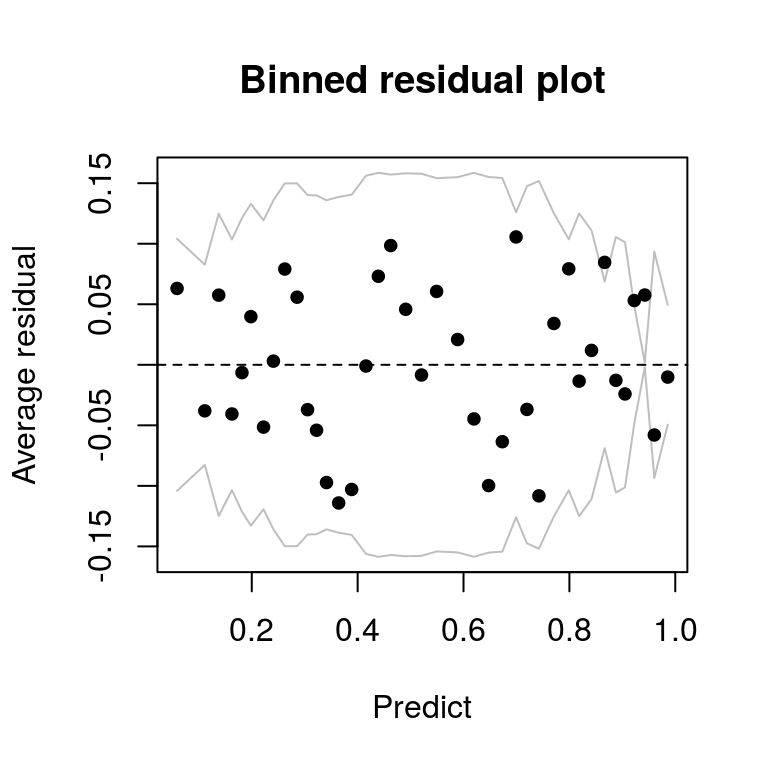

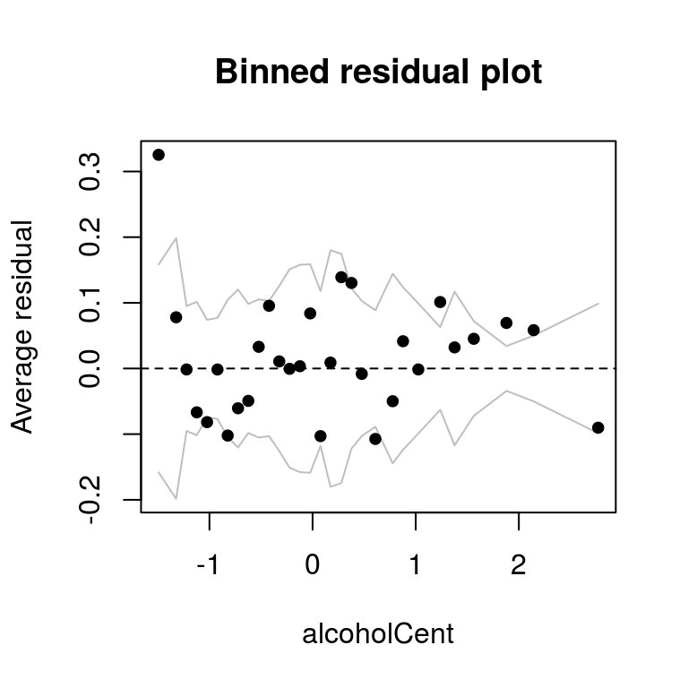

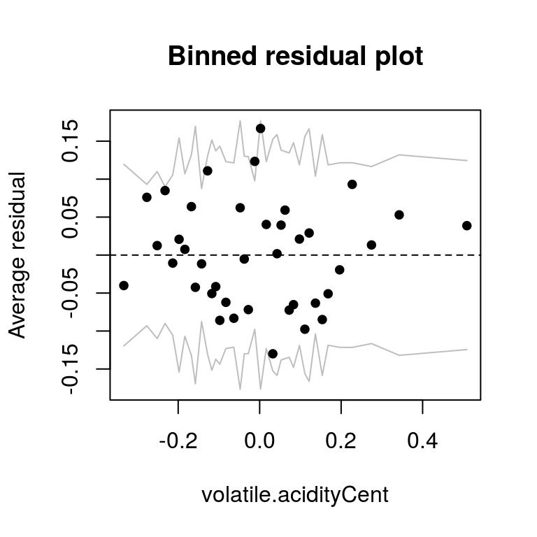

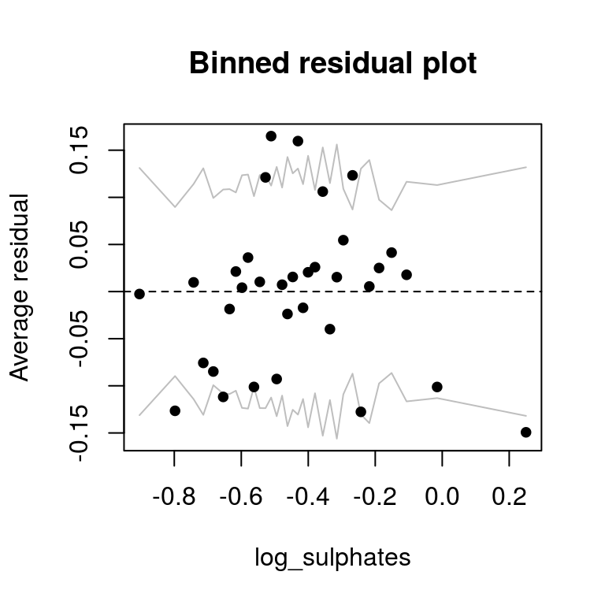

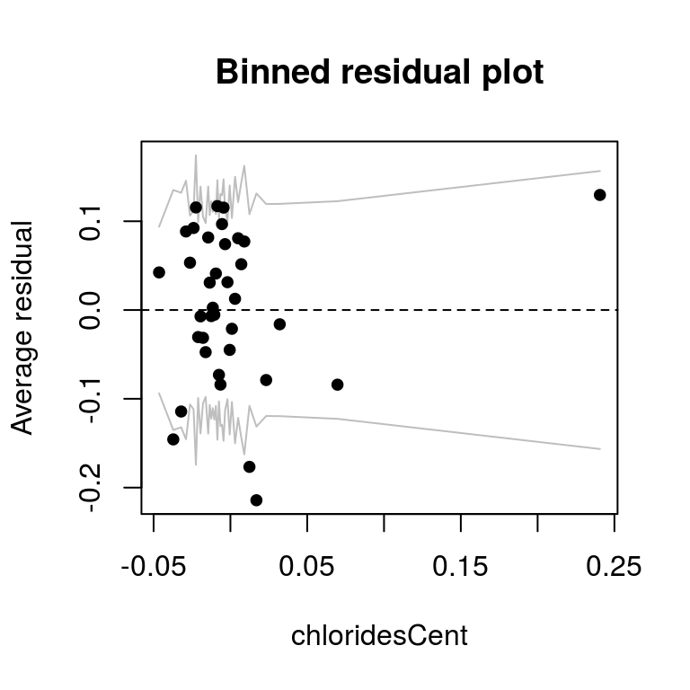

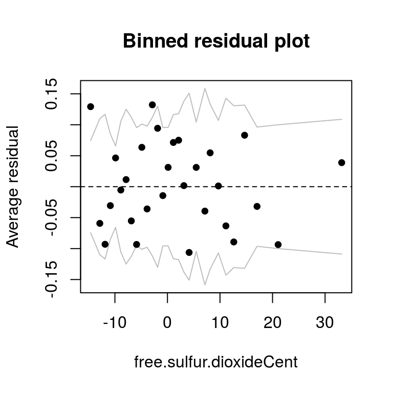

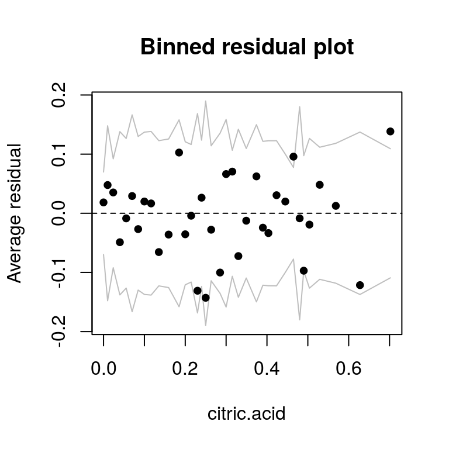

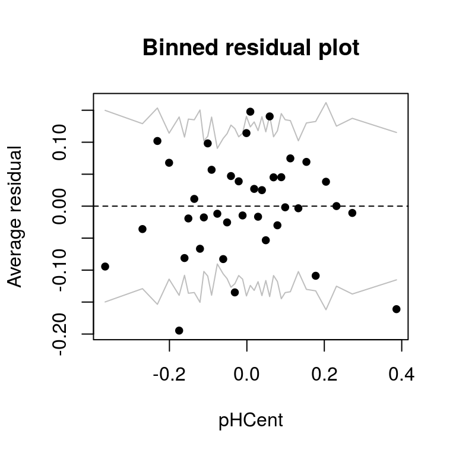

Binned residual plots show random pattern. The binned residual plot of alcoholCent seems to have an outlier on the top left and the binned residual plot of chloridesCent has an outlier on the far right. Overall, however, there is no major concerns of violations of assumptions.

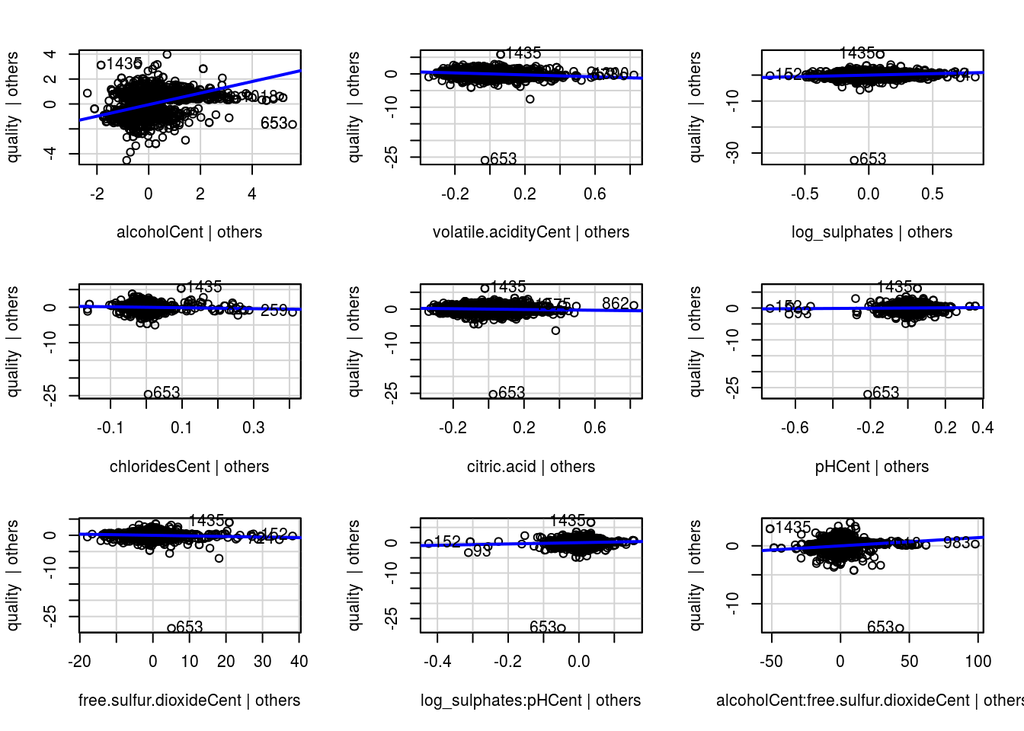

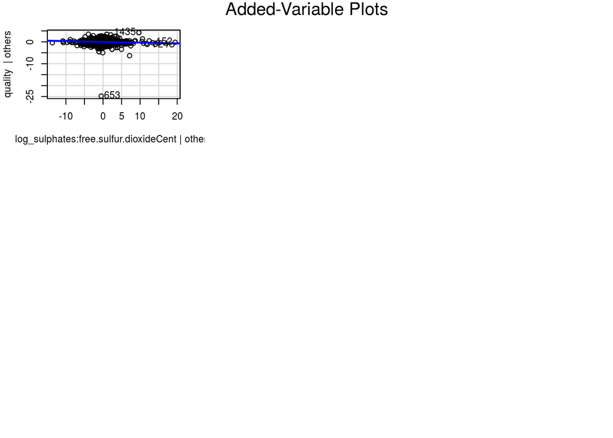

```r
# use AV Plot to identify problematic observations
avPlots(modellg.final)
```

We can see observations 653 and 1435 are consistently identified in av plots. We might consider removing these points if they are influential.

```r
# influence points
data <- data %>%
  mutate(leverage = hatvalues(modellg.final),
         cooks = cooks.distance(modellg.final),
         stand.resid = rstandard(modellg.final),
         obs.num = row_number())
```

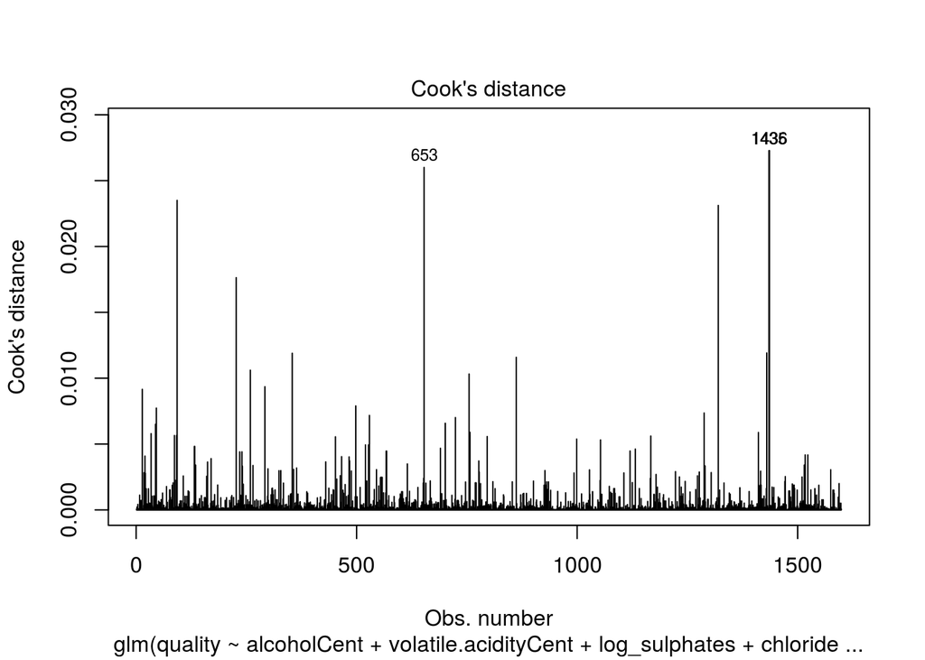

```r
# Cook's Distance
cutoff <- cooks.distance(modellg.final)
plot(modellg.final, which=4, cook.levels=cutoff)
```

We can see that observations 653 and 1435 have noticeably higher Cook’s Distance than other observations. However, their Cook’s Distance is still below 0.05 and is much smaller than the threshold of 1.

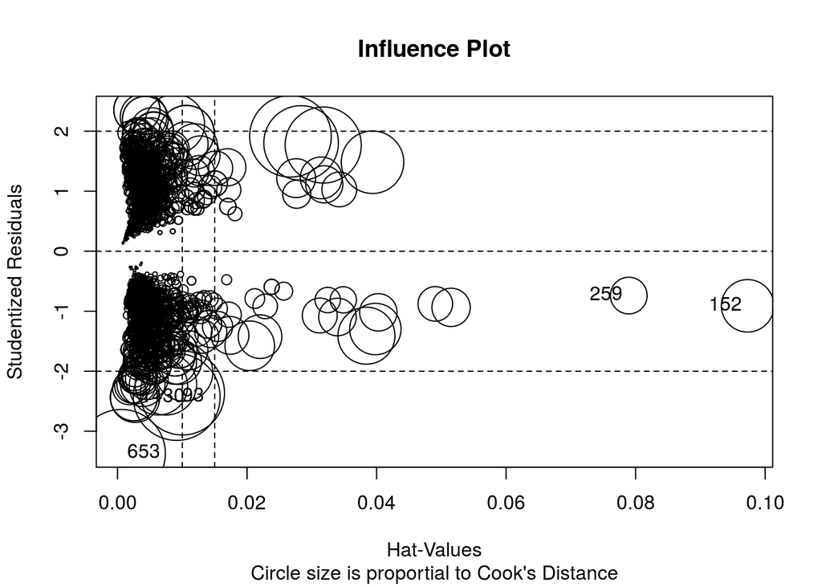

```
##         StudRes          Hat       CookD
## 93   -2.4287943 0.0091359820 0.019405024
## 152  -0.9101741 0.0972935691 0.007088194
## 259  -0.7393382 0.0789403851 0.003462105
## 653  -3.3710586 0.0005899936 0.019939563
## 1430 -2.4435909 0.0027063910 0.006228563
```

```r
# influence plot
influencePlot(modellg1.final, main="Influence Plot", sub="Circle size is proportial to Cook's Distance" )
```

We can see that some observations have high studentized residual value with magnitude greater than 2, but they have very low hat values and acceptable circle size. Observations 259 and 152 have very high leverage (hat values) but are within reasonable studentized residual value and circle size. Observation 653 has high magnitude of studentized residual, but very low leverage and reasonable circle size. Overall, there is no outstanding influence point in the data set, based on considerations of leverage and cook’s distance.

```r
# leverage threshold
threshold <- 0.05
```

Given we have 1599 observations and the above influence plot, we believe 0.05 is a reasonable threshold for leverage.

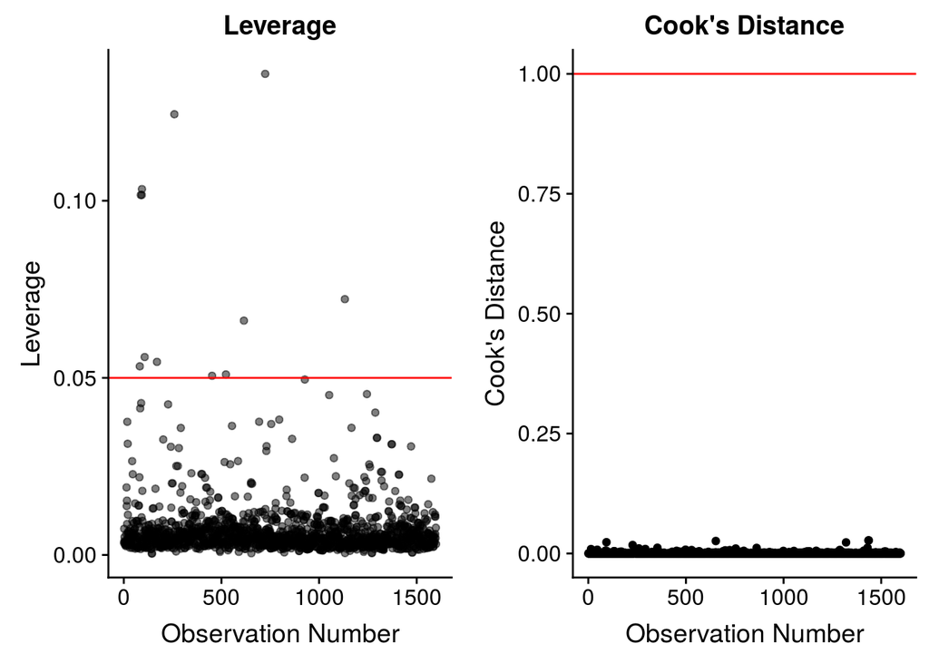

```r
# leverage and cook's distance plots
p1 <- ggplot(data=data, aes(x=obs.num,y=leverage)) +
  geom_point(alpha=0.5) +
  geom_hline(yintercept=threshold,color="red")+
  labs(x="Observation Number",y="Leverage",title="Leverage")

p2 <- ggplot(data=data, aes(x=obs.num,y=cooks)) +
  geom_point() +
  geom_hline(yintercept=1,color="red")+
  labs(x="Observation Number",y="Cook's Distance",title="Cook's Distance")

plot_grid(p1,p2,ncol = 2)
```

Overall, there is no significant influence point.

```r
# multicollinearity
kable(tidy(vif(modellg.final)))
```

| names | x |
| --- | --- |
| alcoholCent | 1.248964 |
| volatile.acidityCent | 1.546294 |
| log_sulphates | 1.544255 |
| chloridesCent | 1.377441 |
| citric.acid | 2.095763 |
| pHCent | 4.868276 |
| free.sulfur.dioxideCent | 5.463815 |
| log_sulphates:pHCent | 4.529185 |
| alcoholCent:free.sulfur.dioxideCent | 1.185423 |
| log_sulphates:free.sulfur.dioxideCent | 5.468602 |

VIF values are small, so there is no major concerns of multicollinearity.

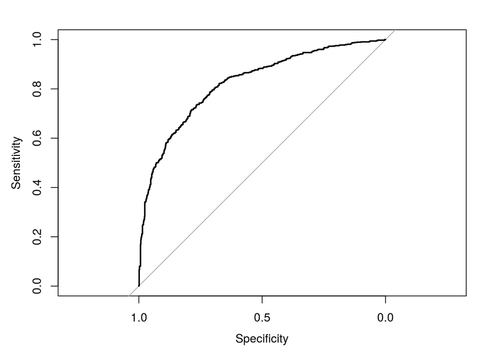

```r
# ROC Curve
ROC.quality <- roc(data$quality, data$pred, plot=T)
```

```r
# area under the curve
ROC.quality$auc
```

```
## Area under the curve: 0.824
```

From the ROC curve and AUC calculation, we can see the curve is fairly close to the top left corner (area under the curve is close to 1). This shows that the logistic model is able to distinguish between good and not good quality, so this is a pretty good model.

# Ordinal Logistic Regression

Since the response variable, quality, is an ordinal variable and has a natural ordering for categories 0,1,…,10, we believe ordinal logistic regression might be a good model.

```r
# create separate indicator variables for each level of quality from 0 to 10
data <- data %>% mutate(qua0 = if_else(quality_dup=="0",1,0),
                        qua1 = if_else(quality_dup=="1",1,0),
                        qua2 = if_else(quality_dup=="2",1,0),
                        qua3 = if_else(quality_dup=="3",1,0),
                        qua4 = if_else(quality_dup=="4",1,0),
                        qua5 = if_else(quality_dup=="5",1,0),
                        qua6 = if_else(quality_dup=="6",1,0),
                        qua7 = if_else(quality_dup=="7",1,0),
                        qua8 = if_else(quality_dup=="8",1,0),
                        qua9 = if_else(quality_dup=="9",1,0),
                        qua10 = if_else(quality_dup=="10",1,0))
```

```r
# log transform sulphates
data <- data %>% mutate(logsulphates = log(sulphates))
```

```r
full.model <- polr(quality_dup ~ volatile.acidityCent + residual.sugarCent + citric.acid + chloridesCent + free.sulfur.dioxideCent + logsulphates + densityCent + pHCent + alcoholCent, data=data)
summary(full.model)
```

```
##
## Re-fitting to get Hessian
```

```
## Call:
## polr(formula = quality_dup ~ volatile.acidityCent + residual.sugarCent +
##     citric.acid + chloridesCent + free.sulfur.dioxideCent + logsulphates +
##     densityCent + pHCent + alcoholCent, data = data)
##
## Coefficients:
##                             Value Std. Error  t value
## volatile.acidityCent    -3.559708   0.382323   -9.311
## residual.sugarCent       0.039004   0.038518    1.013
## citric.acid             -1.044696   0.383176   -2.726
## chloridesCent           -5.630471   1.288220   -4.371
## free.sulfur.dioxideCent -0.009829   0.005003   -1.964
## logsulphates             2.526855   0.267738    9.438
## densityCent              7.282059   0.006762 1076.856
## pHCent                  -1.614162   0.417397   -3.867
## alcoholCent              0.940773   0.058206   16.163
##
## Intercepts:
##     Value     Std. Error t value
## 3|4   -7.3672    0.3792   -19.4278
## 4|5   -5.4168    0.2378   -22.7774
## 5|6   -1.7070    0.1796    -9.5056
## 6|7    1.1447    0.1806     6.3374
## 7|8    4.1818    0.2901    14.4150
##
## Residual Deviance: 3075.33
## AIC: 3103.33
```

```r
# view the model
kable(tidy(full.model),format="markdown",digits=3)
```

| term | estimate | std.error | statistic | coefficient_type |
| --- | --- | --- | --- | --- |
| volatile.acidityCent | -3.560 | 0.382 | -9.311 | coefficient |
| residual.sugarCent | 0.039 | 0.039 | 1.013 | coefficient |
| citric.acid | -1.045 | 0.383 | -2.726 | coefficient |
| chloridesCent | -5.630 | 1.288 | -4.371 | coefficient |
| free.sulfur.dioxideCent | -0.010 | 0.005 | -1.964 | coefficient |
| logsulphates | 2.527 | 0.268 | 9.438 | coefficient |
| densityCent | 7.282 | 0.007 | 1076.856 | coefficient |
| pHCent | -1.614 | 0.417 | -3.867 | coefficient |
| alcoholCent | 0.941 | 0.058 | 16.163 | coefficient |
| 3\|4 | -7.367 | 0.379 | -19.428 | zeta |
| 4\|5 | -5.417 | 0.238 | -22.777 | zeta |
| 5\|6 | -1.707 | 0.180 | -9.506 | zeta |
| 6\|7 | 1.145 | 0.181 | 6.337 | zeta |
| 7\|8 | 4.182 | 0.290 | 14.415 | zeta |

We see there are 5 possible intercepts/models. We also observe the magnitude of the test statistic for densityCent is significantly higher than the test statistic magnitude of other variables.

```r
# parameter estimates with confidence level
confint.default(full.model)
```

```
##
## Re-fitting to get Hessian
```

```
##                               2.5 %        97.5 %
## volatile.acidityCent    -4.30904797 -2.8103676079
## residual.sugarCent      -0.03649083  0.1144982941
## citric.acid             -1.79570605 -0.2936853656
## chloridesCent           -8.15533546 -3.1056061496
## free.sulfur.dioxideCent -0.01963536 -0.0000225394
## logsulphates             2.00209844  3.0516122956
## densityCent              7.26880475  7.2953126134
## pHCent                  -2.43224430 -0.7960796749
## alcoholCent              0.82669108  1.0548542685
```

```r
# obtain p-values
tidy(coeftest(full.model))
```

```
##
## Re-fitting to get Hessian
```

```
## # A tibble: 14 x 5
##    term                    estimate std.error statistic   p.value
##    <chr>                      <dbl>     <dbl>     <dbl>     <dbl>
##  1 volatile.acidityCent    -3.56      0.382       -9.31 1.27e- 20
##  2 residual.sugarCent       0.0390    0.0385       1.01 3.11e-  1
##  3 citric.acid             -1.04      0.383       -2.73 6.40e-  3
##  4 chloridesCent           -5.63      1.29        -4.37 1.24e-  5
##  5 free.sulfur.dioxideCent -0.00983   0.00500     -1.96 4.95e-  2
##  6 logsulphates             2.53      0.268        9.44 3.81e- 21
##  7 densityCent              7.28      0.00676   1077.   0.
##  8 pHCent                  -1.61      0.417       -3.87 1.10e-  4
##  9 alcoholCent              0.941     0.0582      16.2  9.22e- 59
## 10 3|4                     -7.37      0.379      -19.4  4.49e- 84
## 11 4|5                     -5.42      0.238      -22.8  7.68e-115
## 12 5|6                     -1.71      0.180       -9.51 1.99e- 21
## 13 6|7                      1.14      0.181        6.34 2.34e- 10
## 14 7|8                      4.18      0.290       14.4  4.17e- 47
```

p-values of residual.sugarCent and free.sulfur.dioxideCent are above or very close to the 0.05 threshold. So, consistent with the conclusion from confidence interval test, we will remove these two variables.

```r
# new model
model.new <- polr(quality_dup ~ volatile.acidityCent + citric.acid + chloridesCent + logsulphates + densityCent + pHCent + alcoholCent, data=data)
summary(model.new)
```

```
##
## Re-fitting to get Hessian
```

```
## Call:
## polr(formula = quality_dup ~ volatile.acidityCent + citric.acid +
##     chloridesCent + logsulphates + densityCent + pHCent + alcoholCent,
##     data = data)
##
## Coefficients:
##                        Value Std. Error t value
## volatile.acidityCent -3.5492    0.39401 -9.0078
## citric.acid          -1.0502    0.42387 -2.4776
## chloridesCent        -5.5002    1.29868 -4.2352
## logsulphates          2.4545    0.27258  9.0044
## densityCent          27.1861   37.35271  0.7278
## pHCent               -1.6756    0.41636 -4.0244
## alcoholCent           0.9704    0.06902 14.0601
##
## Intercepts:
##     Value    Std. Error t value
## 3|4  -7.3335   0.3797   -19.3141
## 4|5  -5.3778   0.2377   -22.6283
## 5|6  -1.6728   0.1792    -9.3332
## 6|7   1.1731   0.1808     6.4879
## 7|8   4.2018   0.2909    14.4452
##
## Residual Deviance: 3079.241
## AIC: 3103.241
```

```r
# confidence interval test
confint.default(model.new)
```

```
##
## Re-fitting to get Hessian
```

```
##                            2.5 %      97.5 %
## volatile.acidityCent  -4.3214421  -2.7769461
## citric.acid           -1.8809411  -0.2193927
## chloridesCent         -8.0455683  -2.9548239
## logsulphates           1.9201967   2.9887055
## densityCent          -46.0238753 100.3960737
## pHCent                -2.4916499  -0.8595573
## alcoholCent            0.8351188   1.1056612
```

The 95% confidence interval test shows that densityCent contains zero, so it is not a significant predictor. We will remove it from the model.

```r
# final model without densityCent
final.model <- polr(quality_dup ~ volatile.acidityCent + citric.acid + chloridesCent + logsulphates + pHCent + alcoholCent, data=data)
summary(final.model)
```

```
##
## Re-fitting to get Hessian
```

```
## Call:
## polr(formula = quality_dup ~ volatile.acidityCent + citric.acid +
##     chloridesCent + logsulphates + pHCent + alcoholCent, data = data)
##
## Coefficients:
##                        Value Std. Error t value
## volatile.acidityCent -3.4719    0.37898  -9.161
## citric.acid          -0.9100    0.37734  -2.412
## chloridesCent        -5.6128    1.28750  -4.359
## logsulphates          2.4961    0.26684   9.354
## pHCent               -1.6781    0.41617  -4.032
## alcoholCent           0.9433    0.05806  16.249
##
## Intercepts:
##     Value    Std. Error t value
## 3|4  -7.3077   0.3776   -19.3524
## 4|5  -5.3536   0.2350   -22.7820
## 5|6  -1.6545   0.1776    -9.3183
## 6|7   1.1930   0.1789     6.6704
## 7|8   4.2252   0.2892    14.6087
##
## Residual Deviance: 3079.772
## AIC: 3101.772
```

```r
# confidence interval of the final model
confint.default(final.model)
```

```
##
## Re-fitting to get Hessian
```

```
##                           2.5 %     97.5 %
## volatile.acidityCent -4.2147344 -2.7291586
## citric.acid          -1.6496053 -0.1704656
## chloridesCent        -8.1362900 -3.0893761
## logsulphates          1.9730761  3.0190574
## pHCent               -2.4937700 -0.8624326
## alcoholCent           0.8295594  1.0571394
```

None of these variables contain zero in the 95% confidence interval, so they are all significant predictors of the log-odds of wine quality falling at or below level i vs. otherwise.

```r
# view the final model
kable(tidy(final.model))
```

| term | estimate | std.error | statistic | coefficient_type |
| --- | --- | --- | --- | --- |
| volatile.acidityCent | -3.4719465 | 0.3789804 | -9.161283 | coefficient |
| citric.acid | -0.9100354 | 0.3773385 | -2.411722 | coefficient |
| chloridesCent | -5.6128331 | 1.2875017 | -4.359476 | coefficient |
| logsulphates | 2.4960668 | 0.2668369 | 9.354280 | coefficient |
| pHCent | -1.6781013 | 0.4161652 | -4.032297 | coefficient |
| alcoholCent | 0.9433494 | 0.0580572 | 16.248626 | coefficient |
| 3\|4 | -7.3076570 | 0.3776090 | -19.352446 | zeta |
| 4\|5 | -5.3535918 | 0.2349923 | -22.781990 | zeta |
| 5\|6 | -1.6544846 | 0.1775529 | -9.318261 | zeta |
| 6\|7 | 1.1930150 | 0.1788522 | 6.670397 | zeta |
| 7\|8 | 4.2252323 | 0.2892268 | 14.608717 | zeta |

$log(\frac{P(quality\leq3)}{P(quality>3)})=-7.3076570-[-3.4719465*volatile.acidityCent - 0.9100354*citric.acid -5.6128331*chloridesCent + 2.4960668*logsulphates - 1.6781013 *pHCent + 0.9433494*alcoholCent]$ $log(\frac{P(quality\leq4)}{P(quality>4)})=-5.3535918-[-3.4719465*volatile.acidityCent - 0.9100354*citric.acid -5.6128331*chloridesCent + 2.4960668*logsulphates - 1.6781013 *pHCent + 0.9433494*alcoholCent]$ $log(\frac{P(quality\leq5)}{P(quality>5)})=-1.6544846-[-3.4719465*volatile.acidityCent - 0.9100354*citric.acid -5.6128331*chloridesCent + 2.4960668*logsulphates - 1.6781013 *pHCent + 0.9433494*alcoholCent]$ $log(\frac{P(quality\leq6)}{P(quality>6)})=1.1930150-[-3.4719465*volatile.acidityCent - 0.9100354*citric.acid -5.6128331*chloridesCent + 2.4960668*logsulphates - 1.6781013 *pHCent + 0.9433494*alcoholCent]$ $log(\frac{P(quality\leq7)}{P(quality>7)})=4.2252323-[-3.4719465*volatile.acidityCent - 0.9100354*citric.acid -5.6128331*chloridesCent + 2.4960668*logsulphates - 1.6781013 *pHCent + 0.9433494*alcoholCent]$

```r
# obtain the confidence interval
ci <- confint(final.model)
```

```
##
## Re-fitting to get Hessian
```

```r
# display odds ratio and CI
exp(cbind(OR = coef(final.model), ci))
```

```
##                                OR        2.5 %      97.5 %
## volatile.acidityCent  0.031056520 0.0147180458  0.06504432
## citric.acid           0.402509962 0.1916288608  0.84146190
## chloridesCent         0.003650712 0.0002864615  0.04451706
## logsulphates         12.134671385 7.2182523021 20.55385338
## pHCent                0.186728185 0.0823285361  0.42099502
## alcoholCent           2.568570261 2.2948102329  2.88147848
```

For one unit increase in volatile.acidity (the amount of acetic acid in the wine), the odds of the wine falling at or below quality i vs. otherwise multiply by a factor of 0.031056520, given that all other variables are held constant.

For one unit increase in citric.acid, the odds of the wine falling at or below quality i vs. otherwise multiply by a factor of 0.402509962, given that all other variables are held constant.

For one unit increase in chlorides, the odds of the wine falling at or below quality i vs. otherwise multiply by a factor of 0.003650712, given that all other variables are held constant.

For one unit increase in pH, the odds of the wine falling at or below quality i multiply by a factor of 0.186728185, given that all other variables are held constant.

For one unit increase in % alcohol content, the odds of the wine falling at or below quality i multiply by a factor of 2.568570261, given that all other variables are held constant.